# Cats vs Dogs CNN

I am currently taking a course to become a cerified TensorFlow developer. This is my most recent project building my own CNN to classify the famous Dogs vs Cats data set. More and better CNN projects should be getting finished and uploaded soon!

```python
# grader-required-cell

import os
import zipfile
import random
import shutil
import tensorflow as tf
from tensorflow.keras.preprocessing.image import ImageDataGenerator
from shutil import copyfile
import matplotlib.pyplot as plt
```

Download the dataset from its original source by running the cell below.

The `zip` file that contains the images is unzipped under the `/tmp` directory.

```python
!wget --no-check-certificate \
    "https://download.microsoft.com/download/3/E/1/3E1C3F21-ECDB-4869-8368-6DEBA77B919F/kagglecatsanddogs_5340.zip" \
    -O "/tmp/cats-and-dogs.zip"

local_zip = '/tmp/cats-and-dogs.zip'
zip_ref   = zipfile.ZipFile(local_zip, 'r')
zip_ref.extractall('/tmp')
zip_ref.close()
```

```
--2024-02-09 18:19:38--  https://download.microsoft.com/download/3/E/1/3E1C3F21-ECDB-4869-8368-6DEBA77B919F/kagglecatsanddogs_5340.zip
Resolving download.microsoft.com (download.microsoft.com)... 104.81.189.162, 2600:1409:d000:2a0::317f, 2600:1409:d000:29f::317f
Connecting to download.microsoft.com (download.microsoft.com)|104.81.189.162|:443... connected.
HTTP request sent, awaiting response... 200 OK
Length: 824887076 (787M) [application/octet-stream]
Saving to: ‘/tmp/cats-and-dogs.zip’

/tmp/cats-and-dogs. 100%[===================>] 786.67M  59.9MB/s    in 16s

2024-02-09 18:19:53 (50.4 MB/s) - ‘/tmp/cats-and-dogs.zip’ saved [824887076/824887076]
```

Now the images are stored within the `/tmp/PetImages` directory. There is a subdirectory for each class, so one for dogs and one for cats.

```python
source_path = '/tmp/PetImages'

source_path_dogs = os.path.join(source_path, 'Dog')
source_path_cats = os.path.join(source_path, 'Cat')

# Deletes all non-image files (there are two .db files bundled into the dataset)
!find /tmp/PetImages/ -type f ! -name "*.jpg" -exec rm {} +

# os.listdir returns a list containing all files under the given path
print(f"There are {len(os.listdir(source_path_dogs))} images of dogs.")
print(f"There are {len(os.listdir(source_path_cats))} images of cats.")
```

```
There are 12500 images of dogs.
There are 12500 images of cats.
```

Creating a directory for cats-v-dogs, and subdirectories for training and validation. These in turn will need subdirectories for 'cats' and 'dogs'.

```python
# Define root directory
root_dir = '/tmp/cats-v-dogs'

# Empty directory to prevent FileExistsError is the function is run several times
if os.path.exists(root_dir):
  shutil.rmtree(root_dir)


def create_train_val_dirs(root_path):
  #input root directory
  #output is nothing, the os package creates file paths, do not need an output

  #create training subdir
  training_path = os.path.join(root_path, 'training')
  os.makedirs(training_path)
  #create validation subdir
  validation_path = os.path.join(root_path, 'validation')
  os.makedirs(validation_path)
  #create subdir of training
  training_dogs_path = os.path.join(training_path, 'dogs')
  os.makedirs(training_dogs_path)
  training_cats_path = os.path.join(training_path, 'cats')
  os.makedirs(training_cats_path)
  #create subdir of validation
  validation_dogs_path = os.path.join(validation_path, 'dogs')
  os.makedirs(validation_dogs_path)
  validation_cats_path = os.path.join(validation_path, 'cats')
  os.makedirs(validation_cats_path)

try:
  create_train_val_dirs(root_path=root_dir)
except FileExistsError:
  print("If this is printed the paths were not created properly")
```

```python
# Test the create_train_val_dirs function

for rootdir, dirs, files in os.walk(root_dir):
    for subdir in dirs:
        print(os.path.join(rootdir, subdir))
```

```
/tmp/cats-v-dogs/validation
/tmp/cats-v-dogs/training
/tmp/cats-v-dogs/validation/cats
/tmp/cats-v-dogs/validation/dogs
/tmp/cats-v-dogs/training/cats
/tmp/cats-v-dogs/training/dogs
```

Looks good!

The `split_data` function which takes in the following arguments:

- SOURCE_DIR: directory containing the files
- TRAINING_DIR: directory that a portion of the files will be copied to (will be used for training)
- VALIDATION_DIR: directory that a portion of the files will be copied to (will be used for validation)
- SPLIT_SIZE: determines the portion of images used for training.

The files will be randomized, so that the training set is a random sample of the files, and the validation set is made up of the remaining files.

I will use 90% of the data to train and 10% for validation

All images will be checked before the cop if they have a zero file length, they will be omitted from the copying process.

```python
def split_data(SOURCE_DIR, TRAINING_DIR, VALIDATION_DIR, SPLIT_SIZE):

  #Splits the data into train and test sets

  #Args:
    #SOURCE_DIR (string): directory path containing the images
    #TRAINING_DIR (string): directory path to be used for training
    #VALIDATION_DIR (string): directory path to be used for validation
    #SPLIT_SIZE (float): proportion of the dataset to be used for training

  #Returns:
    #None


  list_files = os.listdir(SOURCE_DIR)
  #if the file is length 0, remove
  for pic in list_files:
    if os.path.getsize(SOURCE_DIR+pic)<1:
      print(pic +"is zero length, so ignoring.")
      list_files.remove(pic)
      #training length is the split_size * overall length
  training_length = round(SPLIT_SIZE * len(list_files))
  #randomly get the inverse of split size for validation, this makes
  # it faster with less variables iterate through
  validation = random.sample( list_files, len(list_files) - training_length)
  #set training to all clean files, will now remove the ones from validation
  training = list_files
  for pic in validation:
    training.remove(pic)

  #now copy files into training and validation dir

  for file in training:
    #path = os.path.join(SOURCE_DIR, file)
    source = SOURCE_DIR + file
    destination = TRAINING_DIR + file
    copyfile(source, destination)
  for file in validation:
    source = SOURCE_DIR + file
    destination = VALIDATION_DIR + file
    #path = os.path.join(SOURCE_DIR, file)
    copyfile(source, destination)
```

```python
# Define paths
CAT_SOURCE_DIR = "/tmp/PetImages/Cat/"
DOG_SOURCE_DIR = "/tmp/PetImages/Dog/"

TRAINING_DIR = "/tmp/cats-v-dogs/training/"
VALIDATION_DIR = "/tmp/cats-v-dogs/validation/"

TRAINING_CATS_DIR = os.path.join(TRAINING_DIR, "cats/")
VALIDATION_CATS_DIR = os.path.join(VALIDATION_DIR, "cats/")

TRAINING_DOGS_DIR = os.path.join(TRAINING_DIR, "dogs/")
VALIDATION_DOGS_DIR = os.path.join(VALIDATION_DIR, "dogs/")

# Empty directories in case you run this cell multiple times
if len(os.listdir(TRAINING_CATS_DIR)) > 0:
  for file in os.scandir(TRAINING_CATS_DIR):
    os.remove(file.path)
if len(os.listdir(TRAINING_DOGS_DIR)) > 0:
  for file in os.scandir(TRAINING_DOGS_DIR):
    os.remove(file.path)
if len(os.listdir(VALIDATION_CATS_DIR)) > 0:
  for file in os.scandir(VALIDATION_CATS_DIR):
    os.remove(file.path)
if len(os.listdir(VALIDATION_DOGS_DIR)) > 0:
  for file in os.scandir(VALIDATION_DOGS_DIR):
    os.remove(file.path)

# Define proportion of images used for training
split_size = .9

# Run the function
split_data(CAT_SOURCE_DIR, TRAINING_CATS_DIR, VALIDATION_CATS_DIR, split_size)
split_data(DOG_SOURCE_DIR, TRAINING_DOGS_DIR, VALIDATION_DOGS_DIR, split_size)

# function copies rather than moving images so original directories should contain unchanged images
print(f"\n\nOriginal cat's directory has {len(os.listdir(CAT_SOURCE_DIR))} images")
print(f"Original dog's directory has {len(os.listdir(DOG_SOURCE_DIR))} images\n")

# Training and validation splits. Check that the number of images matches the expected output.
print(f"There are {len(os.listdir(TRAINING_CATS_DIR))} images of cats for training")
print(f"There are {len(os.listdir(TRAINING_DOGS_DIR))} images of dogs for training")
print(f"There are {len(os.listdir(VALIDATION_CATS_DIR))} images of cats for validation")
print(f"There are {len(os.listdir(VALIDATION_DOGS_DIR))} images of dogs for validation")
```

```
666.jpgis zero length, so ignoring.
11702.jpgis zero length, so ignoring.


Original cat's directory has 12500 images
Original dog's directory has 12500 images

There are 11249 images of cats for training
There are 11249 images of dogs for training
There are 1250 images of cats for validation
There are 1250 images of dogs for validation
```

Looks good!

It is time for you to code the generators that will yield batches of images, both for training and validation. For this, complete the `train_val_generators` function below.

Something important to note is that the images in this dataset come in a variety of resolutions. I will use the `flow_from_directory` method to standarize `target_size` that will be used to convert each image to this target resolution. **I will use a `target_size` of (150, 150)**.

```python
def train_val_generators(TRAINING_DIR, VALIDATION_DIR):

  #Creates the training and validation data generators

  #Args:
    #TRAINING_DIR (string): directory path containing the training images
    #VALIDATION_DIR (string): directory path containing the testing/validation images

  #Returns:
    #train_generator, validation_generator - tuple containing the generators

  # Instantiate the ImageDataGenerator class
  train_datagen = ImageDataGenerator(rescale= 1./ 255,
                                     rotation_range= 40,
                                     width_shift_range= .2,
                                     height_shift_range= .2,
                                     shear_range= .2,
                                     zoom_range= .2,
                                     horizontal_flip=True,
                                     fill_mode= 'nearest')

  # Pass in t arguments to the flow_from_directory method
  train_generator = train_datagen.flow_from_directory(directory= "/tmp/cats-v-dogs/training/" ,
                                                      batch_size= 1000,
                                                      class_mode= 'binary',
                                                      target_size=(150, 150))

  # Instantiate the ImageDataGenerator class
  validation_datagen = ImageDataGenerator(rescale=1/255)

  # Pass in the arguments to the flow_from_directory method
  validation_generator = validation_datagen.flow_from_directory(directory= "/tmp/cats-v-dogs/validation/",
                                                                batch_size= 1000,
                                                                class_mode='binary',
                                                                target_size=(150, 150))
  return train_generator, validation_generator
```

```python
# Test your generators
train_generator, validation_generator = train_val_generators(TRAINING_DIR, VALIDATION_DIR)
```

```
Found 22498 images belonging to 2 classes.
Found 2500 images belonging to 2 classes.
```

```python
def create_model():
  # DEFINE A KERAS MODEL TO CLASSIFY CATS V DOGS
  # USE AT LEAST 3 CONVOLUTION LAYERS

  ### START CODE HERE

  model = tf.keras.models.Sequential([
    # Note the input shape is the desired size of the image 150x150 with 3 bytes color
    # This is the first convolution
    tf.keras.layers.Conv2D(16, (3,3), activation='relu', input_shape=(150, 150, 3)),
    tf.keras.layers.MaxPooling2D(2, 2),
    # The second convolution
    tf.keras.layers.Conv2D(32, (3,3), activation='relu'),
    tf.keras.layers.MaxPooling2D(2,2),
    # The third convolution
    tf.keras.layers.Conv2D(64, (3,3), activation='relu'),
    tf.keras.layers.MaxPooling2D(2,2),
    # The fourth convolution
    tf.keras.layers.Conv2D(64, (3,3), activation='relu'),
    tf.keras.layers.MaxPooling2D(2,2),
    # The fifth convolution
    tf.keras.layers.Conv2D(64, (3,3), activation='relu'),
    tf.keras.layers.MaxPooling2D(2,2),
    # Flatten the results to feed into a DNN
    tf.keras.layers.Flatten(),
    # 512 neuron hidden layer
    tf.keras.layers.Dense(512, activation='relu'),
    # Only 1 output neuron
    tf.keras.layers.Dense(1, activation='sigmoid'),
  ])


  model.compile(optimizer='adam',
                loss='binary_crossentropy',
                metrics=['accuracy'])

  return model
```

Now it is time to train the model!

Note: ignoring the `UserWarning: Possibly corrupt EXIF data.` warnings.

```python
# Get the untrained model
model = create_model()

# Train the model
# Note that this may take some time.
history = model.fit(train_generator,
                    epochs=15,
                    verbose=1,
                    validation_data=validation_generator)
```

[output not shown]

```
/usr/local/lib/python3.10/dist-packages/PIL/TiffImagePlugin.py:858: UserWarning: Truncated File Read
  warnings.warn(str(msg))
```

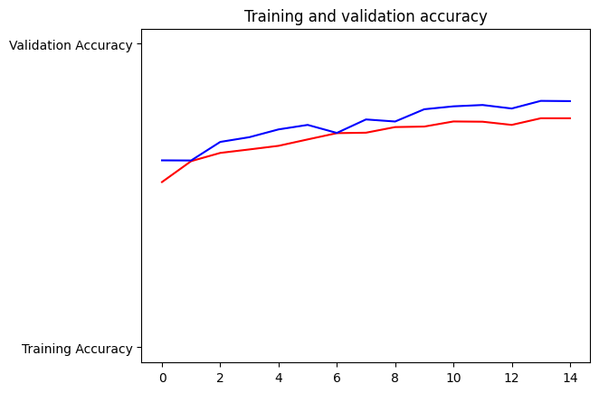

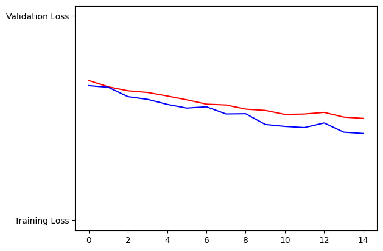

```python
#-----------------------------------------------------------
# Retrieve a list of list results on training and test data
# sets for each training epoch
#-----------------------------------------------------------
acc=history.history['accuracy']
val_acc=history.history['val_accuracy']
loss=history.history['loss']
val_loss=history.history['val_loss']

epochs=range(len(acc)) # Get number of epochs

#------------------------------------------------
# Plot training and validation accuracy per epoch
#------------------------------------------------
plt.plot(epochs, acc, 'r', "Training Accuracy")
plt.plot(epochs, val_acc, 'b', "Validation Accuracy")
plt.title('Training and validation accuracy')
plt.show()
print("")

#------------------------------------------------
# Plot training and validation loss per epoch
#------------------------------------------------
plt.plot(epochs, loss, 'r', "Training Loss")
plt.plot(epochs, val_loss, 'b', "Validation Loss")
plt.show()
```

The legend needs to be fixed. I will fix it for next upload. But For training accuracy the training and validation curves for accuracy have not diverged yet! This suggest the model has not yet fallen victum to overfitting! This means I could(and will by next upload) train for more epochs and the validation accuracy will continue to get better!

```python
def download_history():
  import pickle
  from google.colab import files

  with open('history_augmented.pkl', 'wb') as f:
    pickle.dump(history.history, f)

  files.download('history_augmented.pkl')

download_history()
```